# Bayesian GLMM Part2

Author

Murray Logan

Published

09/09/2025

# 1 Preparations

Load the necessary libraries

```r
library(tidyverse) # for data wrangling etc
library(rstanarm) # for fitting models in STAN
library(cmdstanr) # for cmdstan
library(brms) # for fitting models in STAN
library(standist) # for exploring distributions
library(HDInterval) # for HPD intervals
library(posterior) # for posterior draws
library(coda) # for diagnostics
library(bayesplot) # for diagnostics
library(ggmcmc) # for MCMC diagnostics
library(rstan) # for interfacing with STAN
library(emmeans) # for marginal means etc
library(broom) # for tidying outputs
library(DHARMa) # for residual diagnostics
library(tidybayes) # for more tidying outputs
library(ggeffects) # for partial plots
library(broom.mixed) # for tidying MCMC outputs
library(patchwork) # for multiple plots
library(ggridges) # for ridge plots
library(bayestestR) # for ROPE
library(see) # for some plots
library(easystats) # framework for stats, modelling and visualisation
library(modelsummary)
source("helperFunctions.R")
```

# 2 Scenario

To investigate differential metabolic plasticity in barramundi (*Lates calcarifer*), Norin, Malte, and Clark (2015) exposed juvenile barramundi to various environmental changes (increased temperature, decreased salinity and increased hypoxia) as well as control conditions. Metabolic plasticity was calculated as the percentage difference in standard metabolic rate between the various treatment conditions and the standard metabolic rate under control conditions. They were interested in whether there was a relationship between metabolic plasticity and typical (control) metabolism and how the different treatment conditions impact on this relationship.

A total of 60 barramundi juveniles were subject to each of the three conditions (high temperature, low salinity and hypoxia) in addition to control conditions. Fish mass was also recorded as a covariate as this is known to influence metabolic parameters.

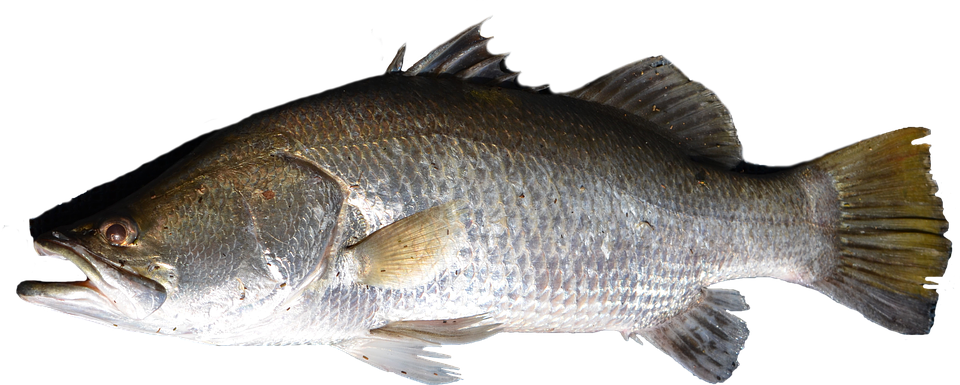

**Figure** 1: Barramundi

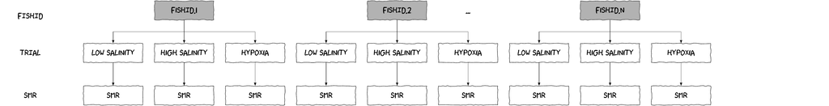

**Figure** 2: Sampling design for the norin data set

**Table** 1: Format of norin.csv data files

| FISHID | MASS | TRIAL | SMR_contr | CHANGE |
| --- | --- | --- | --- | --- |
| 1 | 35.69 | LowSalinity | 5.85 | -31.92 |
| 2 | 33.84 | LowSalinity | 6.53 | 2.52 |
| 3 | 37.78 | LowSalinity | 5.66 | -6.28 |
| .. | .. | .. | .. | .. |
| 1 | 36.80 | HighTemperature | 5.85 | 18.32 |
| 2 | 34.98 | HighTemperature | 6.53 | 19.06 |
| 3 | 38.38 | HighTemperature | 5.66 | 19.03 |
| .. | .. | .. | .. | .. |
| 1 | 45.06 | Hypoxia | 5.85 | -18.61 |
| 2 | 43.51 | Hypoxia | 6.53 | -5.37 |
| 3 | 45.11 | Hypoxia | 5.66 | -13.95 |

**Table** 2: Description of the variables in the norin data file

| **FISHID** | Categorical listing of the individual fish that are repeatedly sampled |
| --- | --- |
| **MASS** | Mass (g) of barramundi. Covariate in analysis |
| **TRIAL** | Categorical listing of the trial (LowSalinity: 10ppt salinity; HighTemperature: 35 degrees; Hypoxia: 45% air-sat. oxygen. |
| **SMR_contr** | Standard metabolic rate (mg/h/39.4 g of fish) under control trial conditions (35 ppt salinity, 29 degrees, normoxia) |
| **CHANGE** | Percentage difference in Standard metabolic rate (mg/h/39.4 g of fish) between Trial conditions and control adjusted for 'regression to the mean'. |

# 3 Read in the data

```r
norin <- read_csv("../data/norin.csv", trim_ws = TRUE)
```

**glimpse**

```r
glimpse(norin)
```

```
Rows: 180
Columns: 5
$ FISHID    <dbl> 1, 2, 3, 4, 5, 6, 7, 8, 9, 10, 11, 12, 13, 14, 15, 16, 17, 1…
$ MASS      <dbl> 35.69, 33.84, 37.78, 26.58, 37.62, 37.68, 30.62, 50.37, 24.9…
$ TRIAL     <chr> "LowSalinity", "LowSalinity", "LowSalinity", "LowSalinity", …
$ SMR_contr <dbl> 5.847466, 6.530707, 5.659556, 6.278200, 4.407336, 4.818589, …
$ CHANGE    <dbl> -31.919389, 2.520929, -6.284968, -4.346675, -3.071329, -15.0…
```

**head**

```r
## Explore the first 6 rows of the data
head(norin)
```

```
# A tibble: 6 × 5
  FISHID  MASS TRIAL       SMR_contr CHANGE
   <dbl> <dbl> <chr>           <dbl>  <dbl>
1      1  35.7 LowSalinity      5.85 -31.9
2      2  33.8 LowSalinity      6.53   2.52
3      3  37.8 LowSalinity      5.66  -6.28
4      4  26.6 LowSalinity      6.28  -4.35
5      5  37.6 LowSalinity      4.41  -3.07
6      6  37.7 LowSalinity      4.82 -15.1
```

**str**

```r
str(norin)
```

```
spc_tbl_ [180 × 5] (S3: spec_tbl_df/tbl_df/tbl/data.frame)
 $ FISHID   : num [1:180] 1 2 3 4 5 6 7 8 9 10 ...
 $ MASS     : num [1:180] 35.7 33.8 37.8 26.6 37.6 ...
 $ TRIAL    : chr [1:180] "LowSalinity" "LowSalinity" "LowSalinity" "LowSalinity" ...
 $ SMR_contr: num [1:180] 5.85 6.53 5.66 6.28 4.41 ...
 $ CHANGE   : num [1:180] -31.92 2.52 -6.28 -4.35 -3.07 ...
 - attr(*, "spec")=
  .. cols(
  ..   FISHID = col_double(),
  ..   MASS = col_double(),
  ..   TRIAL = col_character(),
  ..   SMR_contr = col_double(),
  ..   CHANGE = col_double()
  .. )
 - attr(*, "problems")=<externalptr>
```

**Easystats (datawizard)**

```r
norin |> datawizard::data_codebook()
```

```
norin (180 rows and 5 variables, 5 shown)

ID | Name      | Type      | Missings |           Values |          N
---+-----------+-----------+----------+------------------+-----------
1  | FISHID    | numeric   | 0 (0.0%) |          [1, 60] |        180
---+-----------+-----------+----------+------------------+-----------
2  | MASS      | numeric   | 0 (0.0%) |   [22.52, 64.07] |        180
---+-----------+-----------+----------+------------------+-----------
3  | TRIAL     | character | 0 (0.0%) |  HighTemperature | 60 (33.3%)
   |           |           |          |          Hypoxia | 60 (33.3%)
   |           |           |          |      LowSalinity | 60 (33.3%)
---+-----------+-----------+----------+------------------+-----------
4  | SMR_contr | numeric   | 0 (0.0%) |      [3.98, 6.7] |        180
---+-----------+-----------+----------+------------------+-----------
5  | CHANGE    | numeric   | 0 (0.0%) | [-55.01, 116.33] |        180
---------------------------------------------------------------------
```

**Skim (modelsummary)**

Unique

Missing Pct.

Mean

SD

Min

Median

Max

Histogram

FISHID

60

0

30.5

17.4

1.0

30.5

60.0

[figure not shown]

MASS

175

0

40.2

8.0

22.5

39.3

64.1

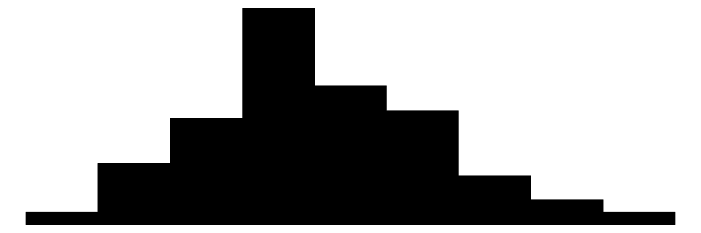

SMR_contr

60

0

5.2

0.6

4.0

5.1

6.7

CHANGE

180

0

19.6

33.8

-55.0

16.4

116.3

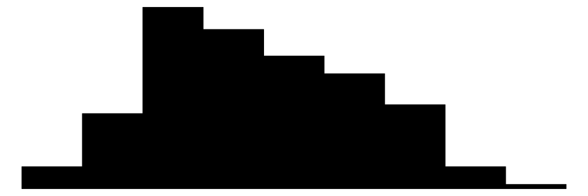

TRIAL

N

%

HighTemperature

60

33.3

Hypoxia

60

33.3

LowSalinity

60

33.3

```r
norin |> modelsummary::datasummary_skim()
```

TRIAL

Unique

Missing Pct.

Mean

SD

Min

Median

Max

Histogram

FISHID

LowSalinity

60

0

30.5

17.5

1.0

30.5

60.0

HighTemperature

60

0

30.5

17.5

1.0

30.5

60.0

Hypoxia

60

0

30.5

17.5

1.0

30.5

60.0

MASS

LowSalinity

60

0

38.1

7.2

23.8

37.6

53.0

[figure not shown]

HighTemperature

60

0

38.3

7.2

22.5

37.7

53.6

[figure not shown]

Hypoxia

60

0

44.2

8.1

28.5

44.0

64.1

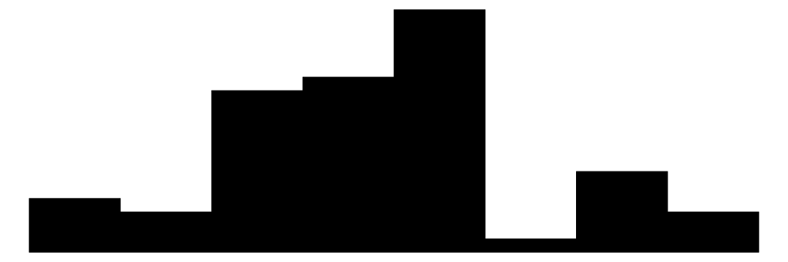

SMR_contr

LowSalinity

60

0

5.2

0.6

4.0

5.1

6.7

HighTemperature

60

0

5.2

0.6

4.0

5.1

6.7

Hypoxia

60

0

5.2

0.6

4.0

5.1

6.7

CHANGE

LowSalinity

60

0

8.2

34.4

-55.0

6.4

99.3

[figure not shown]

HighTemperature

60

0

50.4

22.8

7.0

52.2

116.3

[figure not shown]

Hypoxia

60

0

0.2

17.1

-41.2

-2.7

46.6

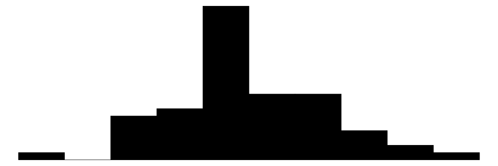

TRIAL

N

%

HighTemperature

60

33.3

Hypoxia

60

33.3

LowSalinity

60

33.3

```r
norin |> modelsummary::datasummary_skim(by = "TRIAL")
```

# 4 Exploratory data analysis

Model formula:
$$y_i \sim{} \mathcal{N}(\mu_i, \sigma^2)\\
\mu_i =\boldsymbol{\beta} \bf{X_i} + \boldsymbol{\gamma} \bf{Z_i}\\
\beta_0 \sim{} \mathcal{N}(16, 35)\\
\beta_{1-6} \sim{} \mathcal{N}(0, 70)\\$$

**Boxplots**

Each of the fish were exposed to each of the three trials (treatments). So lets explore the distributions of responses within each of these trials.

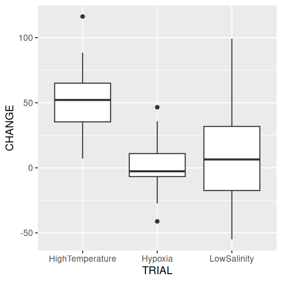

```r
ggplot(norin, aes(y = CHANGE, x = TRIAL)) +
  geom_boxplot()
```

**Conclusions:**

- these seem reasonable enough

**Scatterplots**

The researchers considered that physiological plasticity might be effected by the fishes basal metabolic rate. For example, a fish with relatively high metabolism might have less scope to increase this metabolism than a fish with a lower metabolism. Therefore, the SMR under control conditions (just prior to the specific trial) could be added as a continuous covariate.

Doing so would introduce two additional assumptions:

1. linearity: that the relationship between the response and control SMR is linear (if we intend to model it as a linear trend)
2. homogeneity of slopes: that the rate of change in response associated with a one unit change in control SMR is similar for each trial (unless we include an interaction)

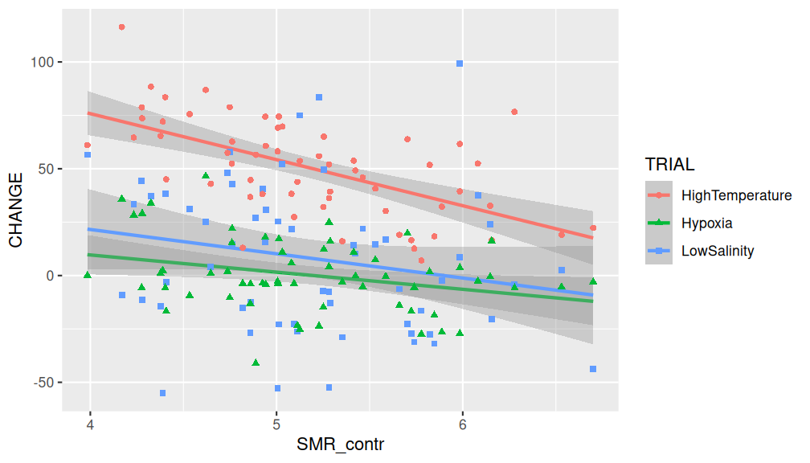

```r
ggplot(norin, aes(y = CHANGE, x = SMR_contr, shape = TRIAL, color = TRIAL)) +
  geom_smooth(method = "lm") +
  geom_point()
```

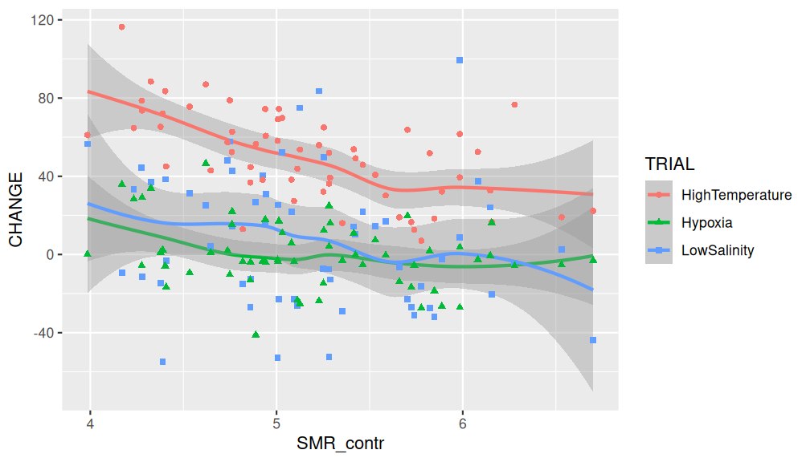

```r
ggplot(norin, aes(y = CHANGE, x = SMR_contr, shape = TRIAL, color = TRIAL)) +
  geom_smooth() +
  geom_point()
```

**Pairs plots**

It might also be worth exploring how consistent the trial effect is across the different fish. This can give us an idea of whether the addition of a random intercept/slope model would be useful.

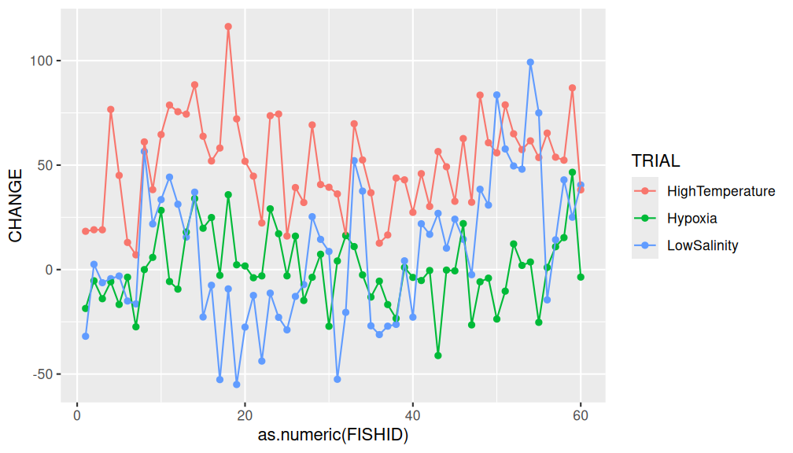

```r
ggplot(norin, aes(y = CHANGE, x = as.numeric(FISHID), color = TRIAL)) +
  geom_point() +
  geom_line()
```

**Conclusions:**

- generally, the difference between control and trial SMR is greatest for the High temperature trial.
- there is less consistency about the relative effects of Hypoxia and Low Salinity.
- hence a random intercept/slope model might be useful.

**Another scatterplot**

- add them as an offset. This will include the covariate in the model, yet will not estimate a partial slope for this predictor. Rather the slope is assumed to be 1. Since the parameter does not need to be estimated, adding a predictor as an offset does not consume any degrees of freedom. However, it does assume that there is a slope of one. This approach can be useful as an alternative to using the response divided by the covariate as the response. That is, it is equivalent to using a response that has been standardised by the covariate, yet still allowing the modelling distribution that would be appropriate for the original response.
- add them as a regular covariate. This will include the covariate in the model and estimate a partial slope parameter just like any other term. Although it will incur a degrees of freedom penalty, it does not assume a slope of 1 and could be modelled as non-linear if appropriate.

Lets explore the relationship between the response and Mass separately for each Trial.

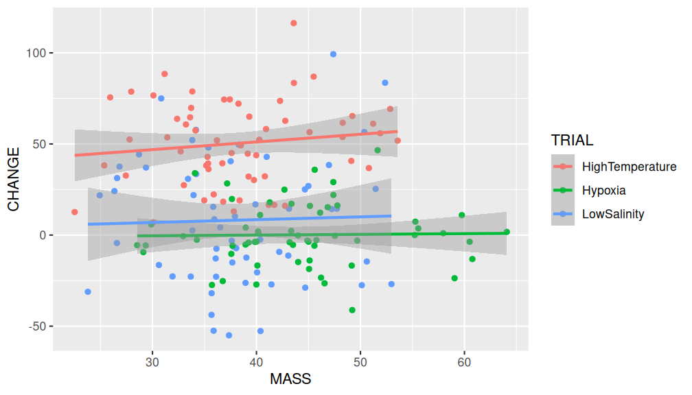

```r
ggplot(norin, aes(y = CHANGE, x = MASS, color = TRIAL)) +
  geom_point() +
  geom_smooth(method = "lm")
```

**Conclusions:**

- there does not seem to be much of a relationship between the response and Mass. Nevertheless, in the presence of control SMN, it might still be a useful covariate at explaining some of the unexplained variability (and thus increasing the power of the model).
- there is no evidence that the response and Mass are related in a non-linear manner.

# 5 Fit the model

**rstanarm**

**Using default priors**

In `rstanarm`, the default priors are designed to be weakly informative. They are chosen to provide moderate regularlization (to help prevent overfitting) and help stabalise the computations.

```r
norin_rstanarm <- stan_glmer(CHANGE ~ (1 | FISHID) + TRIAL * scale(SMR_contr, scale = FALSE) + scale(MASS, scale = FALSE),
  data = norin,
  family = gaussian(),
  iter = 5000,
  warmup = 2000,
  chains = 3,
  thin = 5,
  refresh = 0
)
```

```r
norin_rstanarm |> prior_summary()
```

```
Priors for model 'norin_rstanarm'
------
Intercept (after predictors centered)
  Specified prior:
    ~ normal(location = 20, scale = 2.5)
  Adjusted prior:
    ~ normal(location = 20, scale = 85)

Coefficients
  Specified prior:
    ~ normal(location = [0,0,0,...], scale = [2.5,2.5,2.5,...])
  Adjusted prior:
    ~ normal(location = [0,0,0,...], scale = [178.99,178.99,135.15,...])

Auxiliary (sigma)
  Specified prior:
    ~ exponential(rate = 1)
  Adjusted prior:
    ~ exponential(rate = 0.03)

Covariance
 ~ decov(reg. = 1, conc. = 1, shape = 1, scale = 1)
------
See help('prior_summary.stanreg') for more details
```

This tells us:

- for the intercept (when the family is Gaussian), a normal prior with a mean of 20 and a standard deviation of 85 is used. A value of 2.5 is used for scaling all parameter standard deviations. The value of 20 is based on the mean of the response (`mean(norin$CHANGE)`) and the scaled standard deviation of 85 is based on multiplying the scaling factor by the standard deviation of the response.

```r
2.5 * sd(norin$CHANGE)
```

```
[1] 84.6135
```

- for the coefficients (in this case, just the difference between strong and weak innoculation), the default prior is a normal prior centered around 0 with a standard deviations of 178.99, 178.99, 135.15, 10.60, 34.2 and 34.2 repectively. This is then adjusted for the scale of the data by multiplying the 2.5 by the ratio of the standard deviation of the response by the stanard devation of the numerical dummy variables for the predictor (then rounded).

```r
2.5 * sd(norin$CHANGE) / apply(model.matrix(~ TRIAL * SMR_contr + MASS, norin), 2, sd)
```

```
               (Intercept)               TRIALHypoxia
                       Inf                  178.99305
          TRIALLowSalinity                  SMR_contr
                 178.99305                  135.14517
                      MASS     TRIALHypoxia:SMR_contr
                  10.59372                   34.19156
TRIALLowSalinity:SMR_contr
                  34.19156
```

- the auxillary prior represents whatever additional prior is required for the nominated model. In the case of a Gaussian model, this will be $\sigma$, for negative binomial, it will be the reciprocal of dispersion, for gamma, it will be shape, etc . By default in `rstanarm`, this is a exponential with a rate of 1 which is then adjusted by devision with the standard deviation of the response.

```r
1 / sd(norin$CHANGE)
```

```
[1] 0.02954611
```

**Assessing priors**

Lets now run with priors only so that we can explore the range of values they allow in the posteriors.

```r
norin_rstanarm1 <- update(norin_rstanarm, prior_PD = TRUE)
```

```
Note: uncertainty of error terms are not taken into account. Consider
  setting `interval` to "prediction". This will call `posterior_predict()`
  instead of `posterior_epred()`.
```

```
Data points may overlap. Use the `jitter` argument to add some amount of
  random variation to the location of data points and avoid overplotting.
```

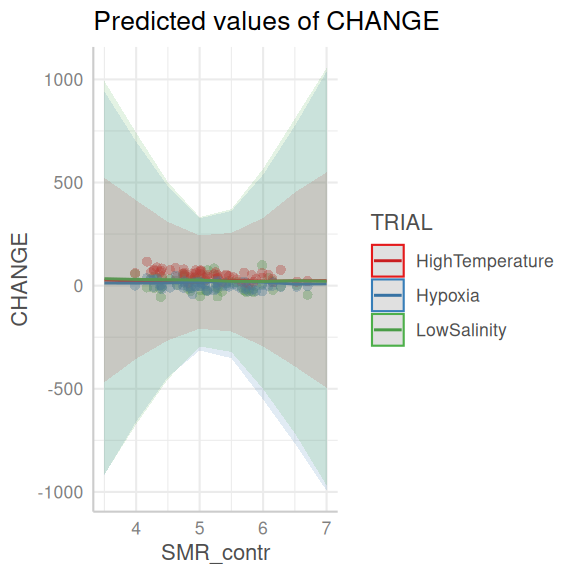

```r
norin_rstanarm1 |>
  ggpredict(~ SMR_contr * TRIAL) |>
  plot(show_data = TRUE)
```

```
Data points may overlap. Use the `jitter` argument to add some amount of
  random variation to the location of data points and avoid overplotting.
```

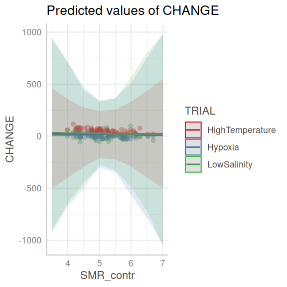

```r
# OR
norin_rstanarm1 |>
  ggemmeans(~ SMR_contr * TRIAL) |>
  plot(show_data = TRUE)
```

**Conclusions:**

**Defining priors**

The following link provides some guidance about defining priors. [https://github.com/stan-dev/stan/wiki/Prior-Choice-Recommendations]

When defining our own priors, we typically do not want them to be scaled.

If we wanted to define our own priors that were less vague, yet still not likely to bias the outcomes, we could try the following priors (mainly plucket out of thin air):

- $\beta_0$: normal centered at 17 with a standard deviation of 35
  - mean of 17: since `median(norin$CHANGE)`
  - sd of 35: since `mad(norin$CHANGE)`
- $\beta_1$: normal centred at 0 with a standard deviation of 70
  - sd of 70: since `sd(norin$CHANGE) / apply(model.matrix(~scale(SMR_contr)*TRIAL + scale(MASS), norin), 2, sd)`
- $\sigma$: exponential with rate of 0.03
  - since `1 / sd(norin$CHANGE)`
- $\Sigma$: decov with:
  - regularization: the exponent for a LKJ prior on the correlation matrix. A value of 1 (default) implies a joint uniform prior
  - concentration: the concentration parameter for a symmetric Dirichlet distribution. A value of 1 (default) implies a joint uniform distribution
  - shape and scale: the shape and scale parameters for a gamma prior on the scale and scale parameters of the decov prior. A value of 1 for both (default) simplifies the gamma prior to a unit-exponential distribution.

I will also overlay the raw data for comparison.

```r
norin_rstanarm2 <- stan_glmer(CHANGE ~ (1 | FISHID) + TRIAL * scale(SMR_contr, scale = FALSE) + offset(MASS),
  data = norin,
  family = gaussian(),
  prior_intercept = normal(17, 35, autoscale = FALSE),
  prior = normal(0, 70, autoscale = FALSE),
  prior_aux = rstanarm::exponential(0.03, autoscale = FALSE),
  prior_covariance = decov(1, 1, 1, 1),
  prior_PD = TRUE,
  iter = 5000,
  warmup = 1000,
  chains = 3,
  thin = 5,
  refresh = 0
)
```

```
Note: uncertainty of error terms are not taken into account. Consider
  setting `interval` to "prediction". This will call `posterior_predict()`
  instead of `posterior_epred()`.
```

```
Data points may overlap. Use the `jitter` argument to add some amount of
  random variation to the location of data points and avoid overplotting.
```

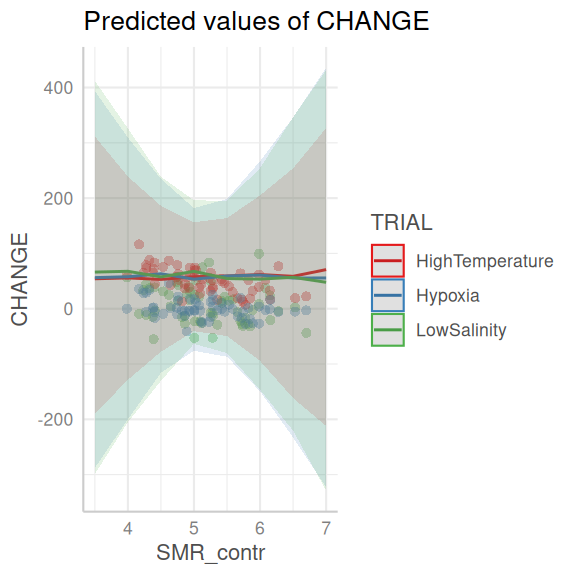

```r
norin_rstanarm2 |>
  ggpredict(~ SMR_contr * TRIAL) |>
  plot(show_data = TRUE)
```

Now lets refit, conditioning on the data.

```r
norin_rstanarm3 <- update(norin_rstanarm2, prior_PD = FALSE)
```

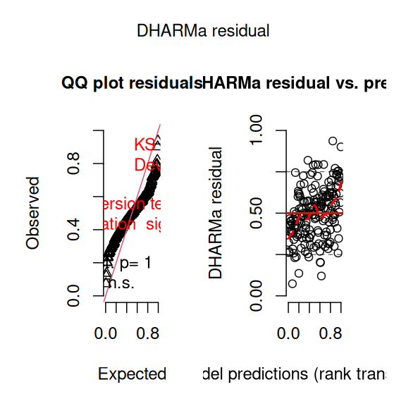

```r
norin_rstanarm4 <- stan_glmer(CHANGE ~ (TRIAL | FISHID) + TRIAL * SMR_contr + offset(MASS),
  data = norin,
  family = gaussian(),
  prior_intercept = normal(17, 35, autoscale = FALSE),
  prior = normal(0, 70, autoscale = FALSE),
  prior_aux = rstanarm::exponential(0.03, autoscale = FALSE),
  prior_covariance = decov(1, 1, 1, 1),
  iter = 5000,
  warmup = 1000,
  chains = 3,
  thin = 5,
  refresh = 0
)
preds <- norin_rstanarm4 |> posterior_predict(ndraws = 250, summary = FALSE)
norin_resids <- createDHARMa(
  simulatedResponse = t(preds),
  observedResponse = norin$CHANGE,
  fittedPredictedResponse = apply(preds, 2, median),
  integerResponse = FALSE
)
plot(norin_resids, quantreg = FALSE)
```

```r
## Clearly an issue here!
```

**Plotting prior and posterior**

```r
get_variables(norin_rstanarm3)
```

```
 [1] "(Intercept)"
 [2] "TRIALHypoxia"
 [3] "TRIALLowSalinity"
 [4] "scale(SMR_contr, scale = FALSE)"
 [5] "TRIALHypoxia:scale(SMR_contr, scale = FALSE)"
 [6] "TRIALLowSalinity:scale(SMR_contr, scale = FALSE)"
 [7] "b[(Intercept) FISHID:1]"
 [8] "b[(Intercept) FISHID:2]"
 [9] "b[(Intercept) FISHID:3]"
[10] "b[(Intercept) FISHID:4]"
[11] "b[(Intercept) FISHID:5]"
[12] "b[(Intercept) FISHID:6]"
[13] "b[(Intercept) FISHID:7]"
[14] "b[(Intercept) FISHID:8]"
[15] "b[(Intercept) FISHID:9]"
```

[output cut: 59 more lines]

```
Drawing from prior...
```

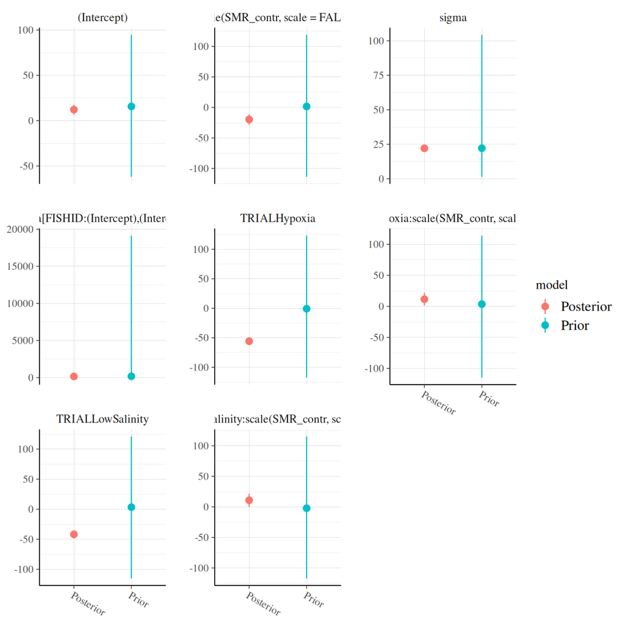

```r
posterior_vs_prior(norin_rstanarm3,
  color_by = "vs", group_by = TRUE,
  facet_args = list(scales = "free_y"),
  regex_pars = "^.Intercept|TRIAL|SMR_contr|MASS|sigma|Sigma"
)
```

**Conclusions:**

- in each case, the prior is substantially wider than the posterior, suggesting that the posterior is not biased towards the prior.

```
Note: uncertainty of error terms are not taken into account. Consider
  setting `interval` to "prediction". This will call `posterior_predict()`
  instead of `posterior_epred()`.
```

```
Data points may overlap. Use the `jitter` argument to add some amount of
  random variation to the location of data points and avoid overplotting.
```

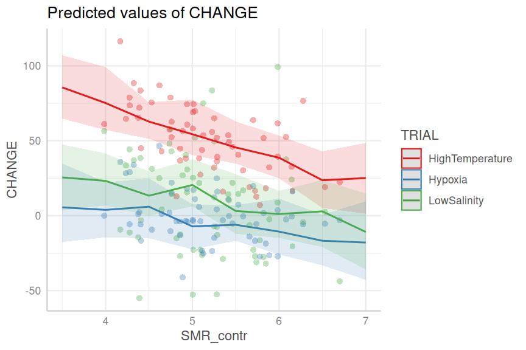

```r
norin_rstanarm3 |>
  ggpredict(~ SMR_contr * TRIAL) |>
  plot(show_data = TRUE)
```

```
Data points may overlap. Use the `jitter` argument to add some amount of
  random variation to the location of data points and avoid overplotting.
```

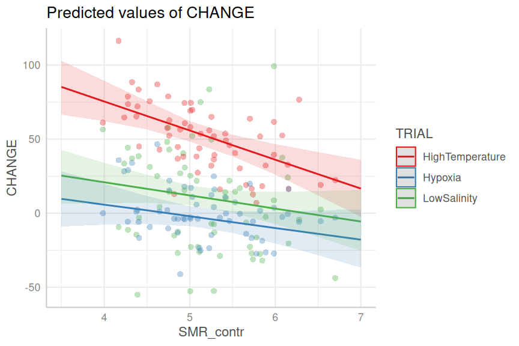

```r
## OR
norin_rstanarm3 |>
  ggemmeans(~ SMR_contr * TRIAL) |>
  plot(show_data = TRUE)
```

**brms**

**Using default priors**

In `brms`, the default priors are designed to be weakly informative. They are chosen to provide moderate regularlization (to help prevent overfitting) and help stabalise the computations.

Unlike `rstanarm`, `brms` models must be compiled before they start sampling. For most models, the compilation of the stan code takes around 45 seconds.

```r
norin_form <- bf(CHANGE ~  (1|FISHID)+TRIAL*SMR_contr+offset(MASS),
                   family = gaussian()
                   )
options(width=100)
norin_form |> get_prior(data=norin)
```

```
                                 prior     class                       coef  group resp dpar nlpar
                                (flat)         b
                                (flat)         b                  SMR_contr
                                (flat)         b               TRIALHypoxia
                                (flat)         b     TRIALHypoxia:SMR_contr
                                (flat)         b           TRIALLowSalinity
                                (flat)         b TRIALLowSalinity:SMR_contr
 student_t(3, -23.7797222222222, 34.5) Intercept
                 student_t(3, 0, 34.5)        sd
                 student_t(3, 0, 34.5)        sd                            FISHID
                 student_t(3, 0, 34.5)        sd                  Intercept FISHID
                 student_t(3, 0, 34.5)     sigma
 lb ub       source
            default
       (vectorized)
       (vectorized)
       (vectorized)
       (vectorized)
       (vectorized)
            default
  0         default
  0    (vectorized)
  0    (vectorized)
  0         default
```

```r
norin_brm <- brm(norin_form,
                 data=norin,
                 iter = 5000,
                 warmup = 1000,
                 chains = 3, cores = 3,
                 thin = 5,
                 refresh = 0,
                 backend = "rstan")
```

This tells us:

**Defining priors**

The following link provides some guidance about defining priors. [https://github.com/stan-dev/stan/wiki/Prior-Choice-Recommendations]

When defining our own priors, we typically do not want them to be scaled.

If we wanted to define our own priors that were less vague, yet still not likely to bias the outcomes, we could try the following priors (mainly plucket out of thin air):

- $\beta_0$: normal centred at 16 with a standard deviation of 35
  - mean of 16: since `median(norin$CHANGE)`
  - sd of 35: since `mad(norin$CHANGE)`
- $\beta_{1-2}$ (TRIAL): normal centred at 0 with a standard deviation of 70
  - sd of 70: since `sd(norin$CHANGE) / apply(model.matrix(~TRIAL*SMR_contr+MASS, norin)[, -1], 2, sd)`
- $\beta_{3}$ (SMR_contr): normal centred at 0 with a standard deviation of 54
  - sd of 54: since `sd(norin$CHANGE) / apply(model.matrix(~TRIAL*SMR_contr+MASS, norin)[, -1], 2, sd)`
- $\beta_{4}$ (MASS): normal centred at 0 with a standard deviation of 4
  - sd of 4: since `sd(norin$CHANGE) / apply(model.matrix(~TRIAL*SMR_contr+MASS, norin)[, -1], 2, sd)`
- $\beta_{5-6}$ (interaction): normal centred at 0 with a standard deviation of 14
  - sd of 14: since `sd(norin$CHANGE) / apply(model.matrix(~TRIAL*SMR_contr+MASS, norin)[, -1], 2, sd)`
- $\sigma$: half-cauchy with parameters 0 and 6 or else a student_t with parameters 0 and 34
  - since `sd(norin$CHANGE)`
- $\sigma_j$: half-cauchy with parameters 0 and 5.8
  - since `sqrt(sd(norin$CHANGE))`
  - we want this prior to have most mass close to zero for the purpose of **regularisation**
- $\Sigma$: decov with:
  - regularization: the exponent for a LKJ prior on the correlation matrix. A value of 1 (default) implies a joint uniform prior
  - concentration: the concentration parameter for a symmetric Dirichlet distribution. A value of 1 (default) implies a joint uniform distribution
  - shape and scale: the shape and scale parameters for a gamma prior on the scale and scale parameters of the decov prior. A value of 1 for both (default) simplifies the gamma prior to a unit-exponential distribution.

Note, for hierarchical models, the model will tend to want to have a large $sigma$ in order to fit the data better. It is a good idea to **regularise** this tendency by applying a prior that has most mass around zero. Suitable candidates include:

- half-t: as the degrees of freedom approach infinity, this will approach a half-normal
- half-cauchy: this is essentially a half-t with 1 degree of freedom
- exponential

I will also overlay the raw data for comparison.

```r
norin |>
  group_by(TRIAL) |>
  summarise(
    median(CHANGE),
    mad(CHANGE)
  )
```

```
# A tibble: 3 × 3
  TRIAL           `median(CHANGE)` `mad(CHANGE)`
  <fct>                      <dbl>         <dbl>
1 HighTemperature            52.2           23.2
2 Hypoxia                    -2.66          13.7
3 LowSalinity                 6.43          38.4
```

```r
norin |>
  group_by(TRIAL, FISHID) |>
  summarise(
    median = median(CHANGE),
    MAD = mad(CHANGE)
  ) |>
  ungroup(FISHID) |>
  summarise(sd(median))
```

```
# A tibble: 3 × 2
  TRIAL           `sd(median)`
  <fct>                  <dbl>
1 HighTemperature         22.8
2 Hypoxia                 17.1
3 LowSalinity             34.4
```

```r
sd(norin$CHANGE) / apply(model.matrix(~ TRIAL * scale(SMR_contr) + scale(MASS), norin)[, -1], 2, sd)
```

```
                     TRIALHypoxia                  TRIALLowSalinity
                         71.59722                          71.59722
                 scale(SMR_contr)                       scale(MASS)
                         33.84540                          33.84540
    TRIALHypoxia:scale(SMR_contr) TRIALLowSalinity:scale(SMR_contr)
                         58.62195                          58.62195
```

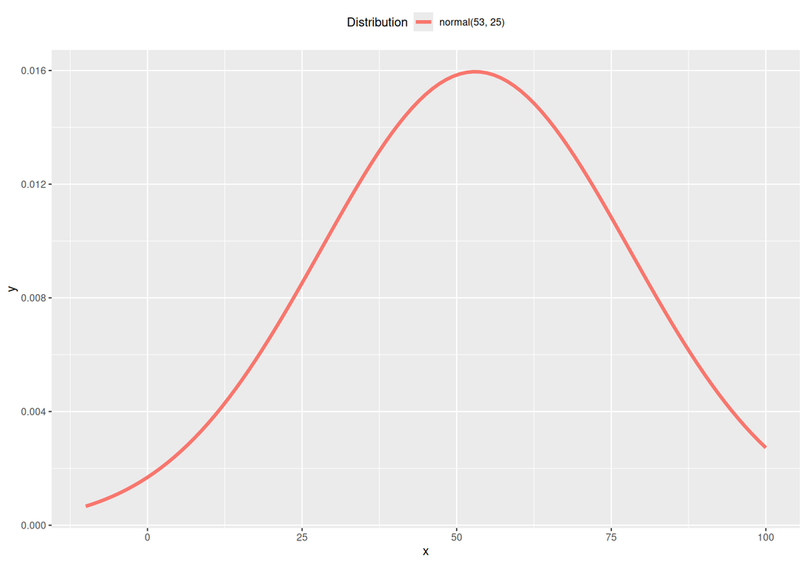

```r
## mad(norin$CHANGE)/apply(model.matrix(~TRIAL*scale(SMR_contr)+scale(MASS), norin)[, -1], 2, mad)

standist::visualize("normal(53, 25)", xlim = c(-10, 100))
```

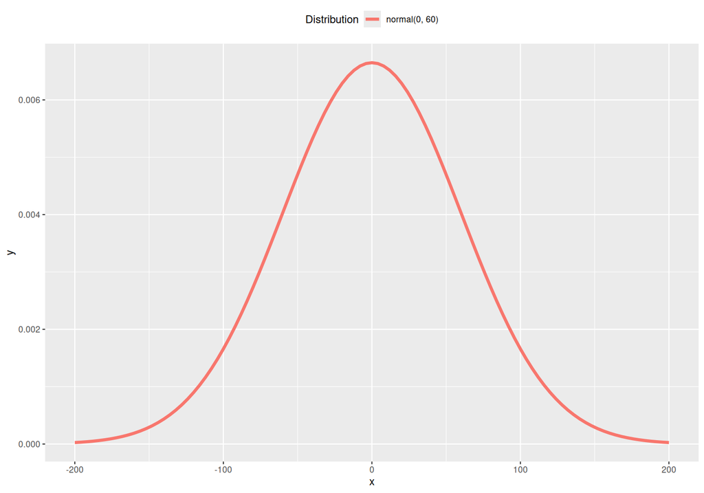

```r
standist::visualize("normal(0, 60)", xlim = c(-200, 200))
```

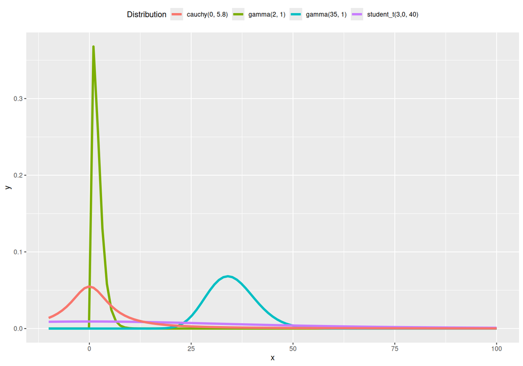

```r
standist::visualize("gamma(2, 1)", "gamma(35, 1)",
  "student_t(3,0, 40)",
  "cauchy(0, 5.8)",
  xlim = c(-10, 100)
)
```

```r
norin_form <- bf(CHANGE ~ (1 | FISHID) + TRIAL * scale(SMR_contr) + scale(MASS),
  family = gaussian()
)
get_prior(norin_form, data = norin)
```

```
                    prior     class                            coef  group resp
                   (flat)         b
                   (flat)         b                       scaleMASS
                   (flat)         b                  scaleSMR_contr
                   (flat)         b                    TRIALHypoxia
                   (flat)         b     TRIALHypoxia:scaleSMR_contr
                   (flat)         b                TRIALLowSalinity
                   (flat)         b TRIALLowSalinity:scaleSMR_contr
 student_t(3, 16.4, 34.5) Intercept
    student_t(3, 0, 34.5)        sd
    student_t(3, 0, 34.5)        sd                                 FISHID
    student_t(3, 0, 34.5)        sd                       Intercept FISHID
    student_t(3, 0, 34.5)     sigma
 dpar nlpar lb ub       source
                       default
                  (vectorized)
                  (vectorized)
                  (vectorized)
                  (vectorized)
                  (vectorized)
                  (vectorized)
                       default
             0         default
             0    (vectorized)
             0    (vectorized)
             0         default
```

```r
priors <- prior(normal(53, 25), class = "Intercept") +
  ## prior(normal(0, 60), class = 'b', coef = 'TRIALHypoxia') +
  ## prior(normal(0, 70), class = 'b', coef = 'TRIALLowSalinity') +
  ## prior(normal(0, 54), class = 'b', coef = 'SMR_contr') +
  ## prior(normal(0, 4), class = 'b', coef = 'MASS') +
  prior(normal(0, 60), class = "b") +
  prior(student_t(3, 0, 40), class = "sd") +
  prior(student_t(3, 0, 40), class = "sigma")
## prior(gamma(35, 1), class = 'sigma') +
## prior(cauchy(0, 5.8), class = 'sd')
norin_brm2 <- brm(norin_form,
  data = norin,
  prior = priors,
  sample_prior = "only",
  iter = 5000,
  warmup = 1000,
  chains = 3, cores = 3,
  thin = 5,
  refresh = 0,
  backend = "rstan"
)
```

Note in the above model, the output may have included a warning message alerting us the presence of **divergent transitions**. Divergent transitions are an indication that the sampler has encountered poor sampling conditions - the more divergent transitions, the more severe the issue.

Typically, divergent transitions are the result of either:

- a miss-specified model
- priors that permit the sampler to drift into unsupported areas
- complex posterior “features” (with high degrees of curvature) for which the sampler was inadequately tuned during the warmup phase

Accordingly, these divergent transitions can be addressed by either:

- reviewing the model structure
- adopting tighter priors
- increase the **adaptive delta** from the default of 0.8 to closer to 1. The adaptive delta defines the average acceptance probability that the sampler should aspire to during the warmup phase. Increasing the adaptive delta results in a smaller step size (and thus fewer divergences and more robust samples) however it will also result in slower sampling speeds.

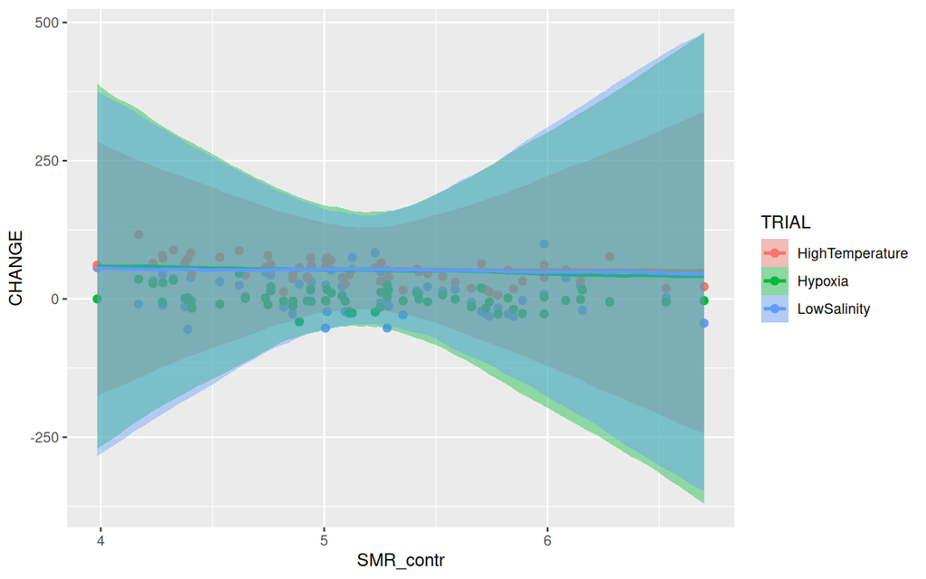

```r
norin_brm2 |>
  conditional_effects(~"SMR_contr:TRIAL") |>
  plot(points = TRUE)
```

```
Note: uncertainty of error terms are not taken into account. Consider
  setting `interval` to "prediction". This will call `posterior_predict()`
  instead of `posterior_epred()`.
```

```
Data points may overlap. Use the `jitter` argument to add some amount of
  random variation to the location of data points and avoid overplotting.
```

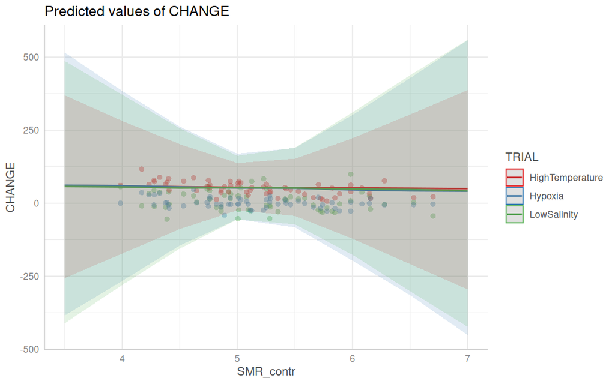

```r
norin_brm2 |>
  ggpredict(~ SMR_contr * TRIAL) |>
  plot(show_data = TRUE)
```

```r
norin_brm3 <- update(norin_brm2,
  sample_prior = "yes",
  control = list(adapt_delta = 0.99),
  refresh = 0,
  cores = 3
)
```

```
The desired updates require recompiling the model
```

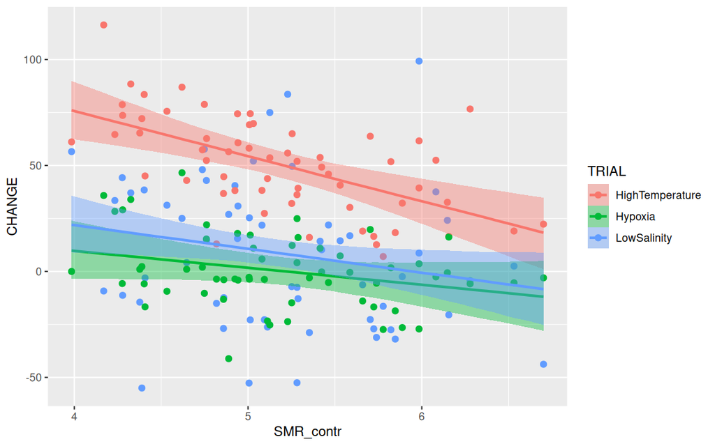

```r
norin_brm3 |>
  conditional_effects(~"SMR_contr:TRIAL") |>
  plot(points = TRUE)
```